```python
from mosaic import *
OS2023(1)
```

# 1. 操作系统概述

**背景回顾**：大家已经有多年的操作系统使用经验，也知道 “操作系统” 是一门很重要的课程，但却无法回答 “操作系统到底是什么”、“为什么重要” 这样的问题。我们将在一学期的时间里回答这些问题，并建立操作系统相关的基本概念、思想方法和编程技巧。

**本讲内容**：个人/课程简介、操作系统的发展历史，回答三个问题：

- (Why): 为什么要学操作系统？
- (What): 到底什么是操作系统？
- (How): 怎么学操作系统？

```python
slideshow('1.1')
```

[interactive chart not shown]

```python
slideshow('1.2')
```

[interactive chart not shown]

### Demo：数学概念的探索与发现

```python
# Life is short; you need Python.
import z3
import numpy as np
import sympy as sp
import matplotlib.pyplot as plt

x = sp.symbols('x')

def plot(f, points, draw_label=True, draw_points=True):
    """Plot a sympy symbolic polynomial f."""

    xmin = min([x_ for x_, _ in points], default=-1) - 0.1
    xmax = max([x_ for x_, _ in points], default=1) + 0.1

    xs = np.arange(xmin, xmax, (xmax - xmin) / 100)
    ys = [f.subs(x, x_) for x_ in xs]

    plt.grid(True)
    plt.plot(xs, ys)
    if draw_points:
        plt.scatter(
            [x_ for x_, y_ in points],
            [y_ for x_, y_ in points],
        )
    if draw_label:
        for x_, y_ in points:
            plt.text(x_, y_, f'$({x_},{y_})$', va='bottom', ha='center')
        plt.title(f'$y = {sp.latex(f)}$')
```

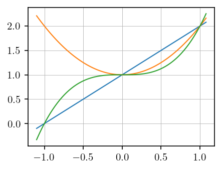

```python
plot(x + 1, [], draw_label=False)
plot(x**2 + 1, [], draw_label=False)
plot(x**3 + 1, [], draw_label=False)
```

```python
def interpolate(n, xs, ys):
    """Return a polynomial that passes through all given points."""
    n = max(n, len(xs), len(ys))
    if len(xs) == 0: xs = [sp.symbols(f'x{i}') for i in range(n)]
    if len(ys) == 0: ys = [sp.symbols(f'y{i}') for i in range(n)]
    vs = [sp.symbols(f'a{i}') for i in range(n)]
    power = list(range(n))

    cons = [
        sum(
            v * (x_ ** k) for v, k in zip(vs, power)
        ) - y
            for x_, y in zip(xs, ys)
    ]

    sol = list(sp.linsolve(cons, vs))[0]

    f = (sum(
        v * (x ** k) for v, k in zip(sol, power)
    ))
    return f
```

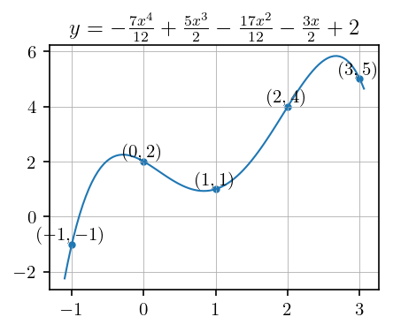

```python
xs = [-1, 0, 1, 2, 3]
ys = [-1, 2, 1, 4, 5]
f = interpolate(0, xs, ys)
plot(f, list(zip(xs, ys)), True)
```

$\displaystyle - 32.4687371003832 x^{19} + 1.19224569061771 \cdot 10^{-6} x^{18} + 213.314280121891 x^{17} - 3.41535766779089 \cdot 10^{-6} x^{16} - 710.678124676993 x^{15} + 3.97666066476177 \cdot 10^{-6} x^{14} + 1579.66070021269 x^{13} - 2.43618259787581 \cdot 10^{-6} x^{12} - 2497.36639730426 x^{11} + 8.4839680525306 \cdot 10^{-7} x^{10} + 2754.31533615693 x^{9} - 1.68401043332267 \cdot 10^{-7} x^{8} - 1983.97996997575 x^{7} + 1.77222637676167 \cdot 10^{-8} x^{6} + 833.325373091812 x^{5} - 7.6785666019985 \cdot 10^{-10} x^{4} - 166.666480422483 x^{3} + 1.71552333970426 \cdot 10^{-13} x^{2} + 9.99999879997548 x + 1.3104421007159 \cdot 10^{-13}$

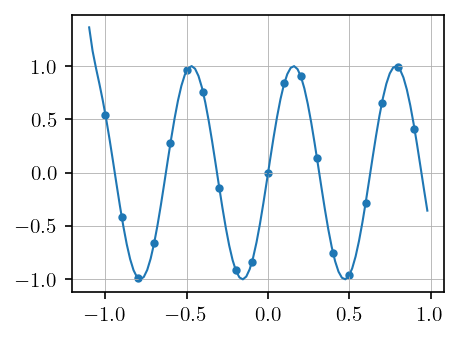

```python
n = 10
xs = np.arange(-1, 1, 1 / n)
ys = np.sin(xs * n)
f = interpolate(0, xs, ys)
plot(f, list(zip(xs, ys)), draw_points=True, draw_label=False)
f
```

```python
sp.simplify(interpolate(3, [], []))
```

$\displaystyle \frac{x^{2} \left(- x_{0} y_{1} + x_{0} y_{2} + x_{1} y_{0} - x_{1} y_{2} - x_{2} y_{0} + x_{2} y_{1}\right) + x \left(x_{0}^{2} y_{1} - x_{0}^{2} y_{2} - x_{1}^{2} y_{0} + x_{1}^{2} y_{2} + x_{2}^{2} y_{0} - x_{2}^{2} y_{1}\right) + x_{0}^{2} x_{1} y_{2} - x_{0}^{2} x_{2} y_{1} - x_{0} x_{1}^{2} y_{2} + x_{0} x_{2}^{2} y_{1} + x_{1}^{2} x_{2} y_{0} - x_{1} x_{2}^{2} y_{0}}{x_{0}^{2} x_{1} - x_{0}^{2} x_{2} - x_{0} x_{1}^{2} + x_{0} x_{2}^{2} + x_{1}^{2} x_{2} - x_{1} x_{2}^{2}}$

```python
slideshow('1.3')
```

[interactive chart not shown]

### Demo：模拟数字系统

```python
demo('logisim', 'i/logisim')
```

如果你阅读示例代码遇到困难，可以想一想今天的大语言模型已经可以 “阅读理解” 程序的行为 (不过也有错误的地方)。你可以相信课堂上的示例已经尽可能做到 “可读”；你只要学习相关的语法特性，就能理解示例代码。

[figure not shown]

### Demo：模拟 RISC-V 指令执行

```python
demo('rvemu', 'i/rvemu')
```

```python
slideshow('1.4')
```

[interactive chart not shown]

### Demo：使用 tar 命令

[figure not shown]

如果一件事很困难，通常是因为没有找到正确的方法。这门课程中绝大部分的内容都可以在互联网上找到适当的学习资料。在互联网/搜索引擎普及的时代，只要掌握 “提出问题” 的能力，就能极快地提升自己。同时，这可能将在 AI 时代被颠覆——AI 可能会猜测你的目的，并且告诉你 “应该去做什么”。

## Take-away Messages

操作系统没有传说中那么复杂 (程序视角：对象 + API，硬件视角：一个 C 程序)

- 为什么要学操作系统：解锁 “实现一切” 的系统编程能力
- 什么是操作系统：应用视角 (一组对象 + API)、机器视角 (一个程序)
- 怎么学操作系统：答案就在代码中

### 课后习题/编程作业

#### 1. 阅读材料

教科书 [Operating Systems: Three Easy Pieces](https://pages.cs.wisc.edu/~remzi/OSTEP/):

- Preface 前言
- 第 1 章 - Dialogue on the Book
- 第 2 章 - Introduction to Operating Systems

延伸阅读：

- *[Harley Hahn's Guide to Unix and Linux](http://www.harley.com/books/sg3.html)*

#### 2. 浏览课程网站

浏览课程网站内容，包括：

- 首页上的信息
- 课程概述
- 参考书与参考资料
- 生存指南

#### 3. 配置编程环境

- 准备好一个可用的 Linux 系统。这个系统将伴随你完成整个《操作系统》课程。可能的方案有：
  - 物理机直接安装的 Linux
  - Windows Subsystem for Linux (应用商店安装 Ubuntu)，通过 ssh 登陆
  - VirtualBox 安装的 Linux 虚拟机，通过 ssh 登陆
  - 网络上购买的 Linux 虚拟主机，通过 ssh 登陆
- 在 Linux 系统中安装必要的软件，包括编译器、git、编辑器、ssh server 等
- 确保你可以在这个环境中编辑、编译和调试 C/C++ 代码

#### 4. 熟悉基础命令行工具

熟悉一些典型的 Linux 的命令行工具：

- 查找文档的工具，例如 tldr 和 man
- UNIX 系统管理的基础工具，请 STFW
- 在命令行使用 gcc 编译、运行一个 C 程序，阅读 `gcc --help` 的帮助信息了解 gcc 支持的主要功能
- GNU Make - 本课程使用 GNU Make 构建项目。我们避免了 CMake 这些在实际项目中很常用，但会导致非常冗长 (也难以理解) 流程的工具
- Git - 本课程所有代码都用 Git 管理；虽然严格意义说你不需要知道 Git 是如何工作的，但学会使用它会对你今后的职业生涯很有帮助

用每一个工具都完成一个基本的功能，并在你愿意的时候读一读 Tutorial 和手册 (我们强烈推荐你收藏上面这些工具的官方文档，并且在你空闲的时候读一读)。此外，在互联网上找到好的 tutorial 会极大幅地提高你的效率；同时你也可以开始尝试定制你的工具 (例如课堂上的 fish 和 tmux 行为就与默认配置有一定区别)。我们为大家提供了一些[参考资料](https://jyywiki.cn/OS/OS_References.html)，其中有一些你用得上的线索，例如 [The Art of Command Line](https://github.com/jlevy/the-art-of-command-line)。

此外，现在已经是 2023 年了。我们也有两条新的建议：

- 如果你希望完成一件事但却不知道怎么做，你可以问搜索引擎 (通常会得到 StackOverflow 上的答案)，或是直接问 ChatGPT！不过要小心，人工智能现在还经常一本正经胡说八道。
- 传统工具的缺点也不断在被改进。特别值得推荐的是 **[Modern Unix](https://github.com/ibraheemdev/modern-unix)**，列出了经典工具的现代替代；但这门课中我们仍然介绍经典工具为主——它们更稳定且具有更好的 “portability”：在你见到的几乎任何平台都可以使用。

#### 5. 编程实践

在你的 Linux 中运行课堂上的代码示例。

[figure not shown]